# Hinge Loss

2026-10-15

课程代码均在如下 GitHub 仓库开源：https://github.com/GHe0000/xmu_machine_learning

项目自动生成网页地址：https://ghe0000.github.io/xmu_machine_learning

## 目录

- 作业要求
- 背景补充
  - Hinge Loss
  - 随机梯度下降
- 数据集准备和划分
  - 计算准备
  - 数据生成
  - 数据集划分
- 特征选取和标准化
- 模型训练
  - Hinge Loss 定义
  - 标签转换
  - 随机梯度下降
- 超参优化
  - 多项式阶数
  - 学习率
- 模型评估
  - 分类边界
  - 混淆矩阵
  - Acc, Precision, Recall， F1
- 和 Logistic 回归模型对比
  - Logicstic 回归模型训练
  - 模型对比
- 结论
- 参考资料和 AI 使用说明
- 致谢
- 附一：问题
  - 问题 1：Batch Size 对 SGD 跳出局部最优的影响
  - 问题 2：特征尺度对 Hinge Loss 最大间隔的影响
- 附二：学习心得

## 作业要求

用 Hinge Loss 训练分类模型。数据集用上次作业的数据集。作业要求：

1）流程完整

2）画出分类带

3）对比 logistic 回归模型的性能

## 背景补充

### Hinge Loss

对于二分类问题，Hinge Loss 要求类别标签取值为 $\{-1,+1\}$，因此首先将原始标签 $y\in\{0,1\}$ 转换为

$$ t=2y-1. $$

定义模型的判别函数为

$$ f(\boldsymbol{x})=\boldsymbol{w}^{\mathsf T}\boldsymbol{\phi}(\boldsymbol{x})+b, $$

其中 $\boldsymbol{\phi}(\boldsymbol{x})$ 为前面构造并标准化的多项式特征.

对于单个样本，Hinge Loss 定义为

$$ \ell_i=\max(0,1-t_if(\boldsymbol{x}_i)). $$

因此，整个训练集上的平均损失函数为

$$ J(\boldsymbol{w},b)= \frac1m\sum_{i=1}^{m} \max\left(0,1-t_i(\boldsymbol{w}^{\mathsf T}\boldsymbol{\phi}_i+b)\right). $$

### 随机梯度下降

对于单个样本：

$$ \ell_i=\max(0,1-t_i(\boldsymbol{w}^{\mathsf T}\boldsymbol{\phi}_i+b)). $$

关于模型参数的次梯度可以取为

$$ \frac{\partial\ell_i}{\partial\boldsymbol{w}}= \begin{cases} -t_i\boldsymbol{\phi}_i,&t_if(\boldsymbol{x}_i)<1,\\ 0,&t_if(\boldsymbol{x}_i)\geq1, \end{cases} $$

$$ \frac{\partial\ell_i}{\partial b}= \begin{cases} -t_i,&t_if(\boldsymbol{x}_i)<1,\\ 0,&t_if(\boldsymbol{x}_i)\geq1. \end{cases} $$

利用随机梯度下降更新参数：

$$ \boldsymbol{w}\leftarrow\boldsymbol{w} -\eta\frac{\partial\ell_i}{\partial\boldsymbol{w}}, \qquad b\leftarrow b-\eta\frac{\partial\ell_i}{\partial b}. $$

因此，当 $t_if(\boldsymbol{x}_i)<1$ 时：

$$ \boldsymbol{w}\leftarrow\boldsymbol{w}+\eta t_i\boldsymbol{\phi}_i, \qquad b\leftarrow b+\eta t_i. $$

而当 $t_if(\boldsymbol{x}_i)\geq1$ 时，参数保持不变.

与普通梯度下降不同，随机梯度下降每次仅使用一个随机选取的样本更新参数. 每一轮 Epoch 将训练样本随机打乱，并依次执行参数更新.

## 数据集准备和划分

### 计算准备

导入需要的库，并针对 Jupyter Notebook 进行一些设置.

```python
import numpy as np # 数值计算库
import numba as nb # 引入 jit 来加速函数（如果需要）
import sympy as sym # 符号计算库
import matplotlib as mpl
import matplotlib.pyplot as plt # 图像绘制
from matplotlib.backends.backend_agg import FigureCanvasAgg # 设置图像后端用
import ipywidgets as ipw # 交互控件
from IPython.display import display, Math, Latex # 打印数学公式
import time
import tracemalloc
import matplotlib.text as mtext

import pandas as pd

from io import BytesIO
import matplotlib.animation as animation # 创建动画
from IPython.display import HTML # 动画嵌入
import scipy

from sklearn.datasets import make_moons, make_blobs, make_circles, make_classification

# 使用 mathjax 来在 jupyter notebook 显示数学公式
sym.init_printing(use_latex='mathjax')

# 设置 matplotlib 绘制的图像嵌入到 jupyter notebook 的方式
%matplotlib widget

# 一个工具函数，可以让静态图片不经过 widget 直接嵌入 Jupyter notebook
# 这样图片可以直接存到 nb 文件里，而不是需要运行才能显示（类似 inline）
def display_inline(fig):
    try:
        try:
            fig.canvas.draw()
            fig.canvas.flush_events()
        except Exception:
            pass

        fig.set_canvas(FigureCanvasAgg(fig))
        try:


            if hasattr(mtext, "_get_text_metrics_with_cache_impl"):
                mtext._get_text_metrics_with_cache_impl.cache_clear()
        except Exception:
            pass
        try:
            fig.draw_without_rendering()
        except Exception:
            pass
        fig.tight_layout()
        fig.canvas.draw()
        display(fig)

    finally:
        plt.close(fig)  # 释放 fig，减小资源消耗

# 一个工具函数，用于在 Jupyter 中快速实现公式和字符串混合输出
def display_math(*args):
    parts = []
    for a in args:
        if isinstance(a, str):
            parts.append(a)
        else:
            parts.append(sym.latex(a))
    display(Math("".join(parts)))

# 设置 matplotlib 使用的字体，避免出现中文问题
plt.rcParams.update({
    # 字体
    "font.family": ["SimSun", "Times New Roman"],
    "font.size": 14,
    "mathtext.fontset": "cm",
    "axes.unicode_minus": False,

    # 字号
    "axes.titlesize": 14,
    "axes.labelsize": 14,
    "xtick.labelsize": 14,
    "ytick.labelsize": 14,
    "legend.fontsize": 14,
    "figure.titlesize": 14,
})

# 设置种子，保证可重复性
rng = np.random.default_rng(3407)
```

### 数据生成

根据题目要求，使用上次作业的数据集生成代码，生成数据集

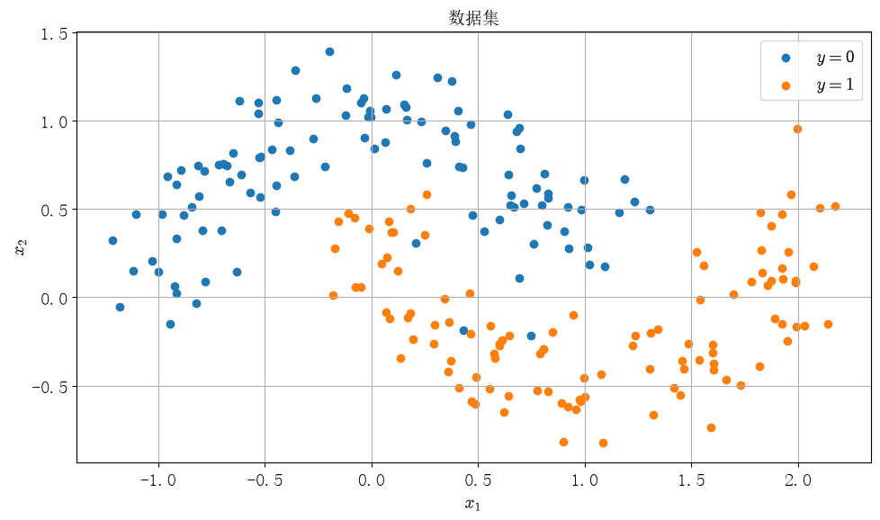

```python
X, y = make_moons(n_samples=220, noise=0.18, random_state=44)

fig, ax = plt.subplots(figsize=(10, 6))
ax.scatter(X[y == 0, 0], X[y == 0, 1], label="$y=0$")
ax.scatter(X[y == 1, 0], X[y == 1, 1], label="$y=1$")
ax.set(xlabel="$x_1$", ylabel="$x_2$", title="数据集")
ax.grid(True); ax.legend()
display_inline(fig)
```

同样，由数据集分布可见，这里的分类边界不是一条直线，因此我们需要使用高阶多项式特征，否则分类效果不好.

### 数据集划分

按 6:2:2 划分训练、验证、测试三个集合.

```python
rng = np.random.default_rng(42)

idx_0 = np.where(y == 0)[0]
idx_1 = np.where(y == 1)[0]

rng.shuffle(idx_0)
rng.shuffle(idx_1)

n_0 = len(idx_0)
n_1 = len(idx_1)

n_0_train = int(0.6 * n_0)
n_0_val = int(0.2 * n_0)

n_1_train = int(0.6 * n_1)
n_1_val = int(0.2 * n_1)

idx_0_train = idx_0[:n_0_train]
idx_0_val = idx_0[n_0_train:n_0_train + n_0_val]
idx_0_test = idx_0[n_0_train + n_0_val:]

idx_1_train = idx_1[:n_1_train]
idx_1_val = idx_1[n_1_train:n_1_train + n_1_val]
idx_1_test = idx_1[n_1_train + n_1_val:]

idx_train = np.concatenate((idx_0_train, idx_1_train))
idx_val = np.concatenate((idx_0_val, idx_1_val))
idx_test = np.concatenate((idx_0_test, idx_1_test))

rng.shuffle(idx_train)
rng.shuffle(idx_val)
rng.shuffle(idx_test)

X_train, y_train = X[idx_train].copy(), y[idx_train].copy()
X_val, y_val = X[idx_val].copy(), y[idx_val].copy()
X_test, y_test = X[idx_test].copy(), y[idx_test].copy()

print("训练集：", X_train.shape)
print("验证集：", X_val.shape)
print("测试集：", X_test.shape)
```

```
训练集： (132, 2)
验证集： (44, 2)
测试集： (44, 2)
```

绘制分类后的数据集：

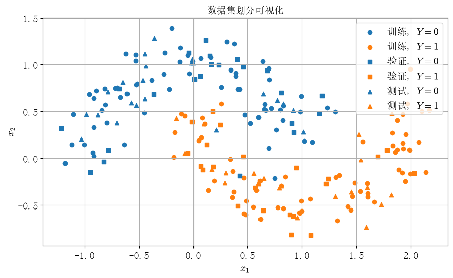

```python
fig, ax = plt.subplots(figsize=(10, 6))

for X_part, y_part, marker, name in [
    (X_train, y_train, "o", "训练"),
    (X_val, y_val, "s", "验证"),
    (X_test, y_test, "^", "测试")
]:
    ax.scatter(
        X_part[y_part == 0, 0], X_part[y_part == 0, 1],
        c="C0", marker=marker, label=fr"{name}, $Y=0$"
    )
    ax.scatter(
        X_part[y_part == 1, 0], X_part[y_part == 1, 1],
        c="C1", marker=marker, label=fr"{name}, $Y=1$"
    )
ax.set_xlabel(r"$x_1$")
ax.set_ylabel(r"$x_2$")
ax.set_title("数据集划分可视化")
ax.grid(True)
ax.legend()
display_inline(fig)
```

## 特征选取和标准化

从图中可以看见，分类边界非线性，因此引入 $x_1,x_2$ 的多项式特征. 对于最高阶数 $p$，选取所有满足

$$ 1\le a+b\le p $$

的单项式 $x_1^a x_2^b$ 作为新的输入特征. 后续通过改变 $p$ 来控制模型的复杂度，并比较不同阶数下模型在验证集上的表现. 本节先取 $p=4$ 作为初始模型.

```python
@nb.njit
def polynomial_features(X, p):
    m = X.shape[0]
    n_features = p * (p + 3) // 2
    Phi = np.empty((m, n_features), dtype=np.float64)
    k = 0
    for degree in range(1, p + 1):
        for a in range(degree, -1, -1):
            b = degree - a
            Phi[:, k] = X[:, 0]**a * X[:, 1]**b
            k += 1
    return Phi
```

```python
p = 4
Phi_train = polynomial_features(X_train, p)
Phi_val = polynomial_features(X_val, p)
Phi_test = polynomial_features(X_test, p)
```

多项式特征的数值尺度可能存在较大差异. 如果直接使用这些特征进行梯度下降，不同特征对应的参数可能具有不同的更新尺度，从而影响优化的稳定性和收敛速度.

因此，对每一个特征分别进行标准化：

$$ \tilde\phi_j=\frac{\phi_j-\mu_j}{\sigma_j} $$

```python
@nb.njit
def standardize_data(X_train, X_val, X_test):
    m, n = X_train.shape
    mean = np.empty(n, dtype=np.float64)
    std = np.empty(n, dtype=np.float64)
    for j in range(n):
        mean[j] = np.mean(X_train[:, j])
        std[j] = np.std(X_train[:, j])
        if std[j] < 1e-12:
            std[j] = 1.0
    X_train_std = (X_train - mean) / std
    X_val_std = (X_val - mean) / std
    X_test_std = (X_test - mean) / std
    return X_train_std, X_val_std, X_test_std, mean, std
```

```python
Phi_train, Phi_val, Phi_test, feature_mean, feature_std = standardize_data(
    Phi_train, Phi_val, Phi_test
)
```

## 模型训练

### Hinge Loss 定义

Hinge Loss 定义为： $$ J(\boldsymbol{w},b)= \frac1m\sum_{i=1}^{m} \max\left(0,1-t_i(\boldsymbol{w}^{\mathsf T}\boldsymbol{\phi}_i+b)\right) $$

```python
@nb.njit
def hinge_loss(X, t, w, b):
    f = X @ w + b
    return np.mean(np.maximum(0.0, 1.0 - t * f))
```

### 标签转换

由于 Hinge Loss 使用的标签是 $\{-1,1\}$，我们的数据集使用的是 $\{0,1\}$，因此通下面式子进行标签转换： $$ t_i = 2 y_i -1 $$

```python
t_train = 2 * y_train - 1
t_val = 2 * y_val - 1
t_test = 2 * y_test - 1
```

### 随机梯度下降

模型训练我们使用随机梯度下降，对于单个样本有：

$$ \boldsymbol{w}\leftarrow\boldsymbol{w} -\eta\frac{\partial\ell_i}{\partial\boldsymbol{w}}, \qquad b\leftarrow b-\eta\frac{\partial\ell_i}{\partial b}. $$

因此，当 $t_if(\boldsymbol{x}_i)<1$ 时：

$$ \boldsymbol{w}\leftarrow\boldsymbol{w}+\eta t_i\boldsymbol{\phi}_i, \qquad b\leftarrow b+\eta t_i. $$

而当 $t_if(\boldsymbol{x}_i)\geq1$ 时，参数保持不变.

每一个 Epoch，我们先打乱样本顺序，然后进行训练. 下一个 Epoch 再次打乱样本顺序，再次进行训练. 每一个 Epoch 结束后，计算上一个 Epoch 的损失.

我们使用 Val Loss 最小来选取最优的 Epoch 轮数.

```python
@nb.njit
def train_hinge_sgd(
    X_train, t_train, X_val, t_val,
    learning_rate, epochs, w_init, b_init, orders
):
    w = w_init.copy()
    b = b_init

    train_loss = np.empty(epochs, dtype=np.float64)
    val_loss = np.empty(epochs, dtype=np.float64)
    val_acc = np.empty(epochs, dtype=np.float64)

    best_w = w.copy()
    best_b = b
    best_val_loss = np.inf

    for epoch in range(epochs):
        # SGD
        for i in orders[epoch]:
            margin = t_train[i] * (X_train[i] @ w + b)
            if margin < 1.0:
                w += learning_rate * t_train[i] * X_train[i]
                b += learning_rate * t_train[i]

        train_loss[epoch] = hinge_loss(X_train, t_train, w, b)
        val_loss[epoch] = hinge_loss(X_val, t_val, w, b)
        val_acc[epoch] = np.mean(
            np.where(X_val @ w + b >= 0, 1, -1) == t_val
        )

        if val_loss[epoch] <= best_val_loss:
            best_val_loss = val_loss[epoch]
            best_w = w.copy()
            best_b = b
    return best_w, best_b, train_loss, val_loss, val_acc
```

进行训练，暂定学习率 $\eta=0.005$，训练 $Epoch=2000$ 轮. 随机初始化，并进行训练.

```python
learning_rate = 0.005
epochs = 2000

rng_sgd = np.random.default_rng(3407)

w_init = rng_sgd.normal(0.0, 0.1, size=Phi_train.shape[1])
b_init = rng_sgd.normal(0.0, 0.1)

orders = np.array([rng_sgd.permutation(len(t_train)) for _ in range(epochs)])

t_start = time.time()
print("开始计算......")
w, b, train_loss, val_loss, val_acc = train_hinge_sgd(
    Phi_train, t_train,
    Phi_val, t_val,
    learning_rate, epochs,
    w_init, b_init, orders
)
print(f"计算结束. 用时 {time.time()-t_start:.3f} s")
```

```
开始计算......
计算结束. 用时 7.697 s
```

绘制训练过程中 Loss 曲线和 Acc 曲线.

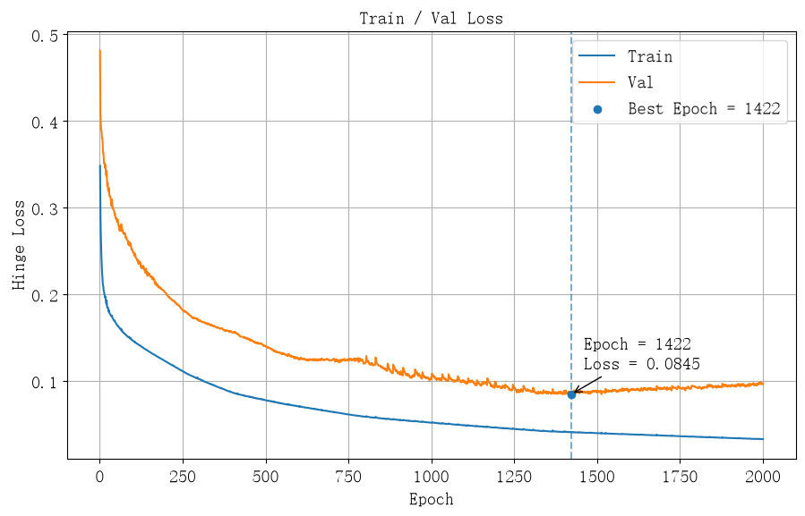

```python
epoch = np.arange(1, epochs + 1)
best_epoch = np.argmin(val_loss) + 1
best_val_loss = val_loss[best_epoch - 1]

fig, ax = plt.subplots(figsize=(10, 6))
ax.plot(epoch, train_loss, label="Train")
ax.plot(epoch, val_loss, label="Val")
ax.scatter(best_epoch, best_val_loss, zorder=3, label=f"Best Epoch = {best_epoch}")

ax.axvline(best_epoch, linestyle="--", alpha=0.6)

ax.annotate(
    f"Epoch = {best_epoch}\nLoss = {best_val_loss:.4f}",
    xy=(best_epoch, best_val_loss),
    xytext=(10, 20),
    textcoords="offset points",
    arrowprops=dict(arrowstyle="->")
)

ax.set_xlabel("Epoch")
ax.set_ylabel("Hinge Loss")
ax.set_title("Train / Val Loss")

ax.grid(True)
ax.legend(loc="upper right")

display_inline(fig)
```

可以发现，随着模型的训练，Train Loss 一直下降，Val Loss 先降后升，呈现标准的“欠学习-过学习”过程.

同时，由于使用了随机梯度下降，可以发现，我们的 Loss 曲线是存在一定毛刺的.

进一步绘制 Acc 曲线.

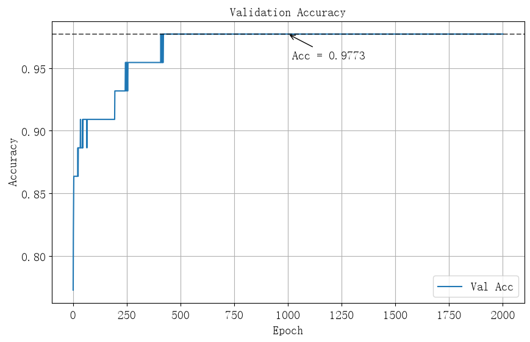

```python
epoch = np.arange(1, epochs + 1)
fig, ax = plt.subplots(figsize=(10, 6))
ax.plot(epoch, val_acc, label="Val Acc")
ax.axhline(val_acc[-1], linestyle="--", alpha=0.6, color="k")
ax.annotate(
    f"Acc = {val_acc[-1]:.4f}",
    xy=(1000, val_acc[-1]),
    xytext=(5, -30),
    textcoords="offset points",
    arrowprops=dict(arrowstyle="->")
)
ax.set_xlabel("Epoch")
ax.set_ylabel("Accuracy")
ax.set_title("Validation Accuracy")
ax.grid(True)
ax.legend(loc="lower right")
display_inline(fig)
```

可以看见，我们的 Acc 平均而言一直在增长，最后稳定在 $0.9773$.

我们绘制出此时的分类边界：

```python
def plot_hinge_decision_boundary(
    X, y, p, w, b, feature_mean, feature_std,
    padding=0.3, grid_size=400, figsize=(10, 6), title=None
):
    x1 = np.linspace(X[:, 0].min() - padding, X[:, 0].max() + padding, grid_size)
    x2 = np.linspace(X[:, 1].min() - padding, X[:, 1].max() + padding, grid_size)
    xx1, xx2 = np.meshgrid(x1, x2)
    X_grid = np.column_stack((xx1.ravel(), xx2.ravel()))

    Phi_grid = polynomial_features(X_grid, p)
    Phi_grid = (Phi_grid - feature_mean) / feature_std

    F = (Phi_grid @ w + b).reshape(xx1.shape)

    cmap = mpl.colors.LinearSegmentedColormap.from_list(
        "decision", ["#83B5FF", "#FFFFFF", "#FFE18A"]
    )

    vlim = max(1.5, 5)
    fig, ax = plt.subplots(figsize=figsize)
    cf = ax.contourf(xx1, xx2, F,
        levels=np.linspace(-vlim, vlim, 61),
        cmap=cmap, extend="both", alpha=0.85
    )

    cbar = fig.colorbar(cf, ax=ax)
    cbar.set_label(r"$f(\mathbf{x})$")
    ax.contour(xx1, xx2, F, levels=[-1, 1], colors="black", linestyles="--", linewidths=1.5)
    ax.contour(xx1, xx2, F, levels=[0], colors="black", linewidths=1.5)
    for label in [0, 1]:
        ax.scatter(X[y == label, 0], X[y == label, 1], c=f"C{label}", s=35, label=fr"$y={label}$")
    ax.plot([], [], "k-", linewidth=2, label=r"$f(\mathbf{x})=0$")
    ax.plot([], [], "k--", linewidth=1.5, label=r"$f(\mathbf{x})=\pm1$")

    ax.set_xlabel(r"$x_1$")
    ax.set_ylabel(r"$x_2$")

    if title is None:
        ax.set_title(f"Hinge Loss Decision Boundary (p={p})")
    else:
        ax.set_title(title)

    ax.set_xlim(x1.min(), x1.max())
    ax.set_ylim(x2.min(), x2.max())
    ax.grid(True, alpha=0.3)
    ax.legend()
    display_inline(fig)
```

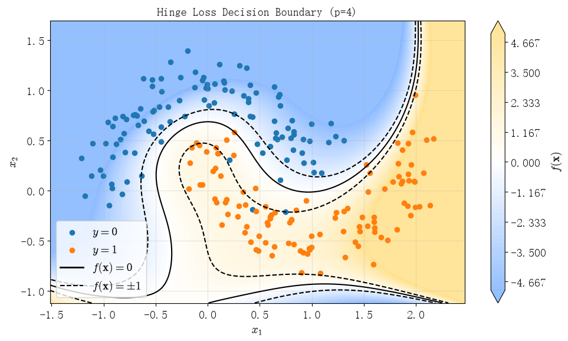

```python
plot_hinge_decision_boundary(X, y, p, w, b, feature_mean, feature_std)
```

可以看见，模型已经基本正确分类出两类点.

## 超参优化

### 多项式阶数

多项式阶数 $p$ 决定了模型能够描述的分类边界复杂程度. 当 $p$ 较小时，模型可能由于表达能力不足而欠拟合；当 $p$ 较大时，则可能出现过拟合.

对于每个阶数，重新生成多项式特征并标准化，然后进行随机梯度下降训练. 记录各模型在验证集损失最小时对应的 Train Loss、Val Loss 和 Val Acc：

为保证不同阶数之间的可比性，各组实验使用相同的随机样本顺序，且共同特征对应的初始权重相同.

```python
@nb.njit(parallel=True)
def scan_polynomial_degree_hinge(
    X_train, t_train, X_val, t_val, X_test,
    p_values, learning_rate, epochs,
    w_init_max, b_init, orders
):
    n = len(p_values)

    train_loss_min = np.empty(n, dtype=np.float64)
    val_loss_min = np.empty(n, dtype=np.float64)
    val_acc_min = np.empty(n, dtype=np.float64)
    best_epoch = np.empty(n, dtype=np.int64)

    for k in nb.prange(n):
        p = p_values[k]

        Phi_train = polynomial_features(X_train, p)
        Phi_val = polynomial_features(X_val, p)
        Phi_test = polynomial_features(X_test, p)

        Phi_train, Phi_val, Phi_test, _, _ = standardize_data(Phi_train, Phi_val, Phi_test)

        n_features = Phi_train.shape[1]
        w_init = w_init_max[:n_features].copy()

        _, _, train_loss, val_loss, val_acc = train_hinge_sgd(
            Phi_train, t_train, Phi_val, t_val,
            learning_rate, epochs, w_init, b_init, orders
        )
        index = 0
        for j in range(epochs):
            if val_loss[j] <= val_loss[index]:
                index = j

        train_loss_min[k] = train_loss[index]
        val_loss_min[k] = val_loss[index]
        val_acc_min[k] = val_acc[index]
        best_epoch[k] = index + 1
    return train_loss_min, val_loss_min, val_acc_min, best_epoch
```

进行扫描：

```python
p_values = np.arange(1, 11)
learning_rate_p = 0.005
epochs_p = 10000
rng_hyper = np.random.default_rng(3407)

n_features_max = p_values[-1] * (p_values[-1] + 3) // 2
w_init_max = rng_hyper.normal(0.0, 0.1, size=n_features_max)
b_init_hyper = rng_hyper.normal(0.0, 0.1)
orders_p = np.array([rng_hyper.permutation(len(t_train)) for _ in range(epochs_p)])

t_start = time.time()
print("开始扫描多项式阶数......")
train_loss_p, val_loss_p, val_acc_p, best_epoch_p = scan_polynomial_degree_hinge(
    X_train, t_train, X_val, t_val, X_test,
    p_values, learning_rate_p, epochs_p,
    w_init_max, b_init_hyper, orders_p
)
best_index_p = np.argmin(val_loss_p)
best_p = int(p_values[best_index_p])
print(f"计算结束. 用时 {time.time() - t_start:.3f} s")
```

```
开始扫描多项式阶数......
计算结束. 用时 10.636 s
```

绘制 Val Loss 和 Val Acc 随多项式阶数 p 的变化.

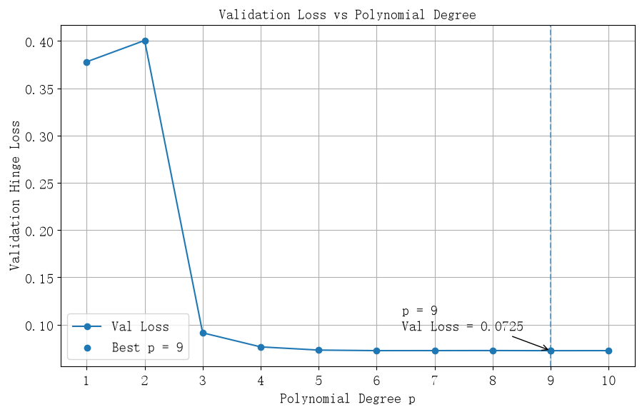

```python
fig, ax = plt.subplots(figsize=(10, 6))

ax.plot(p_values, val_loss_p, marker="o", label="Val Loss")

ax.scatter(
    best_p, val_loss_p[best_index_p],
    zorder=3,
    label=f"Best p = {best_p}"
)

ax.axvline(best_p, linestyle="--", alpha=0.6)

ax.annotate(
    f"p = {best_p}\nVal Loss = {val_loss_p[best_index_p]:.4f}",
    xy=(best_p, val_loss_p[best_index_p]),
    xytext=(-150, 20),
    textcoords="offset points",
    arrowprops=dict(arrowstyle="->")
)

ax.set_xlabel("Polynomial Degree p")
ax.set_ylabel("Validation Hinge Loss")
ax.set_title("Validation Loss vs Polynomial Degree")
ax.set_xticks(p_values)

ax.grid(True)
ax.legend()

display_inline(fig)
```

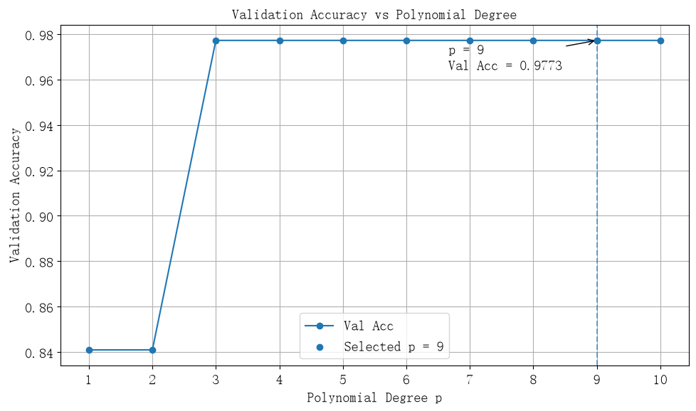

```python
fig, ax = plt.subplots(figsize=(10, 6))

ax.plot(p_values, val_acc_p, marker="o", label="Val Acc")

ax.scatter(
    best_p, val_acc_p[best_index_p],
    zorder=3,
    label=f"Selected p = {best_p}"
)

ax.axvline(best_p, linestyle="--", alpha=0.6)

ax.annotate(
    f"p = {best_p}\nVal Acc = {val_acc_p[best_index_p]:.4f}",
    xy=(best_p, val_acc_p[best_index_p]),
    xytext=(-150, -30),
    textcoords="offset points",
    arrowprops=dict(arrowstyle="->")
)

ax.set_xlabel("Polynomial Degree p")
ax.set_ylabel("Validation Accuracy")
ax.set_title("Validation Accuracy vs Polynomial Degree")
ax.set_xticks(p_values)

ax.grid(True)
ax.legend()

display_inline(fig)
```

从 Hinge Loss 曲线中也可看到“欠拟合-过拟合“的效果. $p=1,2$ 时验证准确率较低，说明仅使用低阶特征难以分开双月牙样本. 当阶数增至 $p=3$ 后，Val Acc 已达到约 $0.9773$，并在更高阶数下基本保持不变；但是 Val Loss 仍随着阶数增加而下降. 在本次扫描范围内，最小 Val Loss 对应 $p=9$，因此后续学习率优化固定该阶数. 这一结果说明仅凭 Val Acc 无法区分这些准确率相同的候选模型，使用 Hinge Loss 可以进一步衡量它们的函数间隔表现.

### 学习率

确定多项式阶数后，继续考察学习率 $\eta$ 对 SGD 训练结果的影响. 学习率过小可能导致在给定的 Epoch 内收敛不充分，学习率过大则可能使参数在最优区域附近来回振荡，甚至出现数值不稳定. 本次固定 $p=9$，仍训练 $10000$ 个 Epoch，学习率取

$$ 10^{-5}\leq\eta\leq1 $$

```python
@nb.njit(parallel=True)
def scan_learning_rate_hinge(
    X_train, t_train, X_val, t_val,
    learning_rates, epochs, w_init, b_init, orders
):
    n = len(learning_rates)

    train_loss_min = np.empty(n, dtype=np.float64)
    val_loss_min = np.empty(n, dtype=np.float64)
    val_acc_min = np.empty(n, dtype=np.float64)
    best_epoch = np.empty(n, dtype=np.int64)

    for k in nb.prange(n):
        _, _, train_loss, val_loss, val_acc = train_hinge_sgd(
            X_train, t_train, X_val, t_val,
            learning_rates[k], epochs,
            w_init, b_init, orders
        )
        index = np.argmin(val_loss)
        train_loss_min[k] = train_loss[index]
        val_loss_min[k] = val_loss[index]
        val_acc_min[k] = val_acc[index]
        best_epoch[k] = index + 1
    return train_loss_min, val_loss_min, val_acc_min, best_epoch
```

```python
p_fixed = 9
epochs_lr = 10000

Phi_train_lr = polynomial_features(X_train, p_fixed)
Phi_val_lr = polynomial_features(X_val, p_fixed)
Phi_test_lr = polynomial_features(X_test, p_fixed)

Phi_train_lr, Phi_val_lr, Phi_test_lr, feature_mean_lr, feature_std_lr = standardize_data(
    Phi_train_lr, Phi_val_lr, Phi_test_lr
)

w_init_lr = w_init_max[:Phi_train_lr.shape[1]].copy()
learning_rates = np.logspace(-5, 0, 31)

t_start = time.time()
print("开始扫描学习率......")
train_loss_lr, val_loss_lr, val_acc_lr, best_epoch_lr = scan_learning_rate_hinge(
    Phi_train_lr, t_train,
    Phi_val_lr, t_val,
    learning_rates, epochs_lr,
    w_init_lr, b_init_hyper, orders_p
)

best_index_lr = np.argmin(val_loss_lr)
best_learning_rate = learning_rates[best_index_lr]
print(f"计算结束. 用时 {time.time() - t_start:.3f} s")
```

```
开始扫描学习率......
计算结束. 用时 8.913 s
```

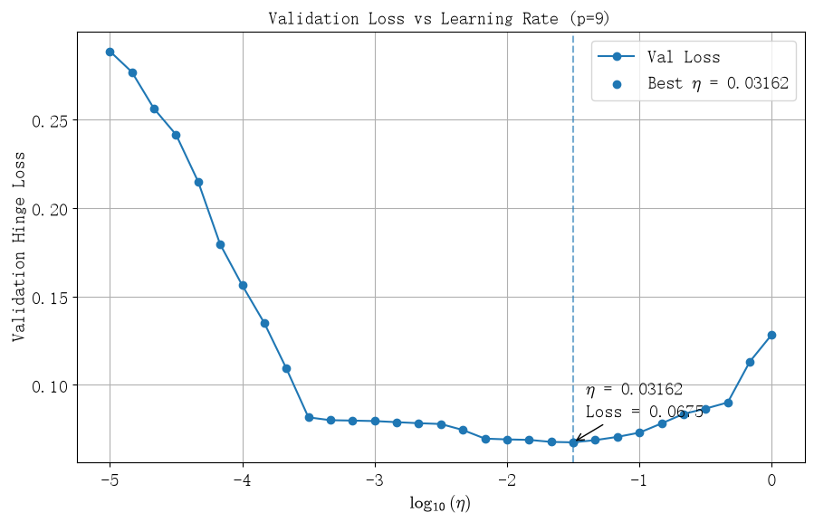

```python
log_lr = np.log10(learning_rates)
best_log_lr = log_lr[best_index_lr]

fig, ax = plt.subplots(figsize=(10, 6))

ax.plot(log_lr, val_loss_lr, marker="o", label="Val Loss")

ax.scatter(
    best_log_lr, val_loss_lr[best_index_lr],
    zorder=3,
    label=fr"Best $\eta$ = {best_learning_rate:.4g}"
)

ax.axvline(best_log_lr, linestyle="--", alpha=0.6)

ax.annotate(
    fr"$\eta$ = {best_learning_rate:.4g}"
    + f"\nLoss = {val_loss_lr[best_index_lr]:.4f}",
    xy=(best_log_lr, val_loss_lr[best_index_lr]),
    xytext=(10, 20),
    textcoords="offset points",
    arrowprops=dict(arrowstyle="->")
)

ax.set_xlabel(r"$\log_{10}(\eta)$")
ax.set_ylabel("Validation Hinge Loss")
ax.set_title(f"Validation Loss vs Learning Rate (p={p_fixed})")

ax.grid(True)
ax.legend()

display_inline(fig)
```

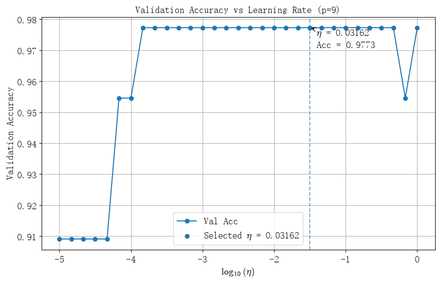

```python
fig, ax = plt.subplots(figsize=(10, 6))

ax.plot(log_lr, val_acc_lr, marker="o", label="Val Acc")

ax.scatter(
    best_log_lr, val_acc_lr[best_index_lr],
    zorder=3,
    label=fr"Selected $\eta$ = {best_learning_rate:.4g}"
)

ax.axvline(best_log_lr, linestyle="--", alpha=0.6)

ax.annotate(
    fr"$\eta$ = {best_learning_rate:.4g}"
    + f"\nAcc = {val_acc_lr[best_index_lr]:.4f}",
    xy=(best_log_lr, val_acc_lr[best_index_lr]),
    xytext=(10, -30),
    textcoords="offset points",
    arrowprops=dict(arrowstyle="->")
)

ax.set_xlabel(r"$\log_{10}(\eta)$")
ax.set_ylabel("Validation Accuracy")
ax.set_title(f"Validation Accuracy vs Learning Rate (p={p_fixed})")

ax.grid(True)
ax.legend()

display_inline(fig)
```

学习率扫描表明，过小的 $\eta$ 使训练在给定轮数内推进较慢，Val Loss 相对较高；随着 $\eta$ 增大，Val Loss 逐渐下降，在过大的学习率下又重新上升. 在本次扫描中最优学习率约为 $\eta=0.03162$，对应 $\log_{10}\eta=-1.5$.

Val Acc 在较宽的学习率范围内保持约 $0.9773$，但 Val Loss 的差异仍然明显. 因此本次最终模型仍按最小 Val Loss 选择学习率.

至此，选定多项式阶数 $p=9$ 和学习率 $\eta\approx0.03162$. 下一步我们评估这个最优模型的分类性能.

## 模型评估

### 分类边界

绘制判别函数

$$ f(\boldsymbol{x})=\boldsymbol{w}^{\mathsf T}\boldsymbol{\phi}_p(\boldsymbol{x})+b $$

在原始二维空间中的等值线. 其中 $f(\boldsymbol{x})=0$ 为分类边界，$f(\boldsymbol{x})=\pm1$ 为函数间隔边界.

相比初始的 $p=4$ 模型，$p=9$ 具有更高的特征维度，可以描述更加复杂的非线性分类边界.

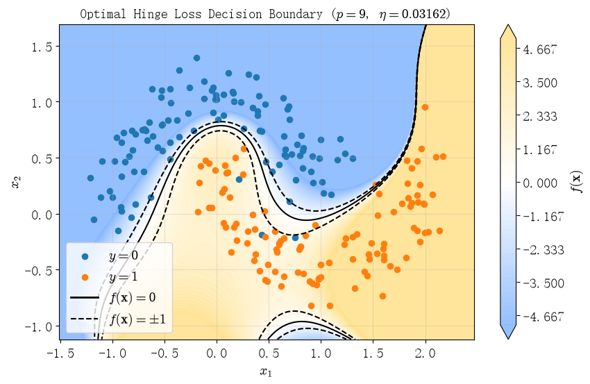

```python
w_best, b_best, train_loss_best, val_loss_best, val_acc_best = train_hinge_sgd(
    Phi_train_lr, t_train,
    Phi_val_lr, t_val,
    best_learning_rate, epochs_lr,
    w_init_lr, b_init_hyper, orders_p
)

best_epoch_final = np.argmin(val_loss_best) + 1
plot_hinge_decision_boundary(
    X, y,
    p_fixed,
    w_best, b_best,
    feature_mean_lr, feature_std_lr,
    title=fr"Optimal Hinge Loss Decision Boundary ($p={p_fixed}$, $\eta={best_learning_rate:.4g}$)"
)
```

从图中可以看到，最优模型的分类边界能够较好地贴合双月牙数据的非线性结构，绝大多数样本位于正确的分类区域内.

与初始模型相比，高阶多项式使分类边界具有更强的弯曲能力，能够进一步调整不同区域的函数间隔.

### 混淆矩阵

为了进一步分析模型的分类错误类型，分别计算 Train、Val、Test 和 All 四组数据的混淆矩阵.

对于二分类问题，以 $y=1$ 为正类、$y=0$ 为负类，混淆矩阵定义为

$$ C= \begin{pmatrix} TN & FP\\ FN & TP \end{pmatrix} $$

其中：

- $TN$（True Negative）：真实为负类，预测为负类.
- $FP$（False Positive）：真实为负类，预测为正类.
- $FN$（False Negative）：真实为正类，预测为负类.
- $TP$（True Positive）：真实为正类，预测为正类.

```python
@nb.njit
def predict_hinge(X, w, b):
    return (X @ w + b >= 0).astype(np.int64)


@nb.njit
def confusion_matrix(y, y_pred):
    TN = np.sum((y == 0) & (y_pred == 0))
    FP = np.sum((y == 0) & (y_pred == 1))
    FN = np.sum((y == 1) & (y_pred == 0))
    TP = np.sum((y == 1) & (y_pred == 1))

    return np.array([
        [TN, FP],
        [FN, TP]
    ])


# Train / Val / Test
y_pred_train = predict_hinge(Phi_train_lr, w_best, b_best)
y_pred_val = predict_hinge(Phi_val_lr, w_best, b_best)
y_pred_test = predict_hinge(Phi_test_lr, w_best, b_best)

# All
y_all = np.concatenate((y_train, y_val, y_test))
y_pred_all = np.concatenate((y_pred_train, y_pred_val, y_pred_test))

confusion_train = confusion_matrix(y_train, y_pred_train)
confusion_val = confusion_matrix(y_val, y_pred_val)
confusion_test = confusion_matrix(y_test, y_pred_test)
confusion_all = confusion_matrix(y_all, y_pred_all)

confusion_list = [
    confusion_train, confusion_val,
    confusion_test, confusion_all
]
```

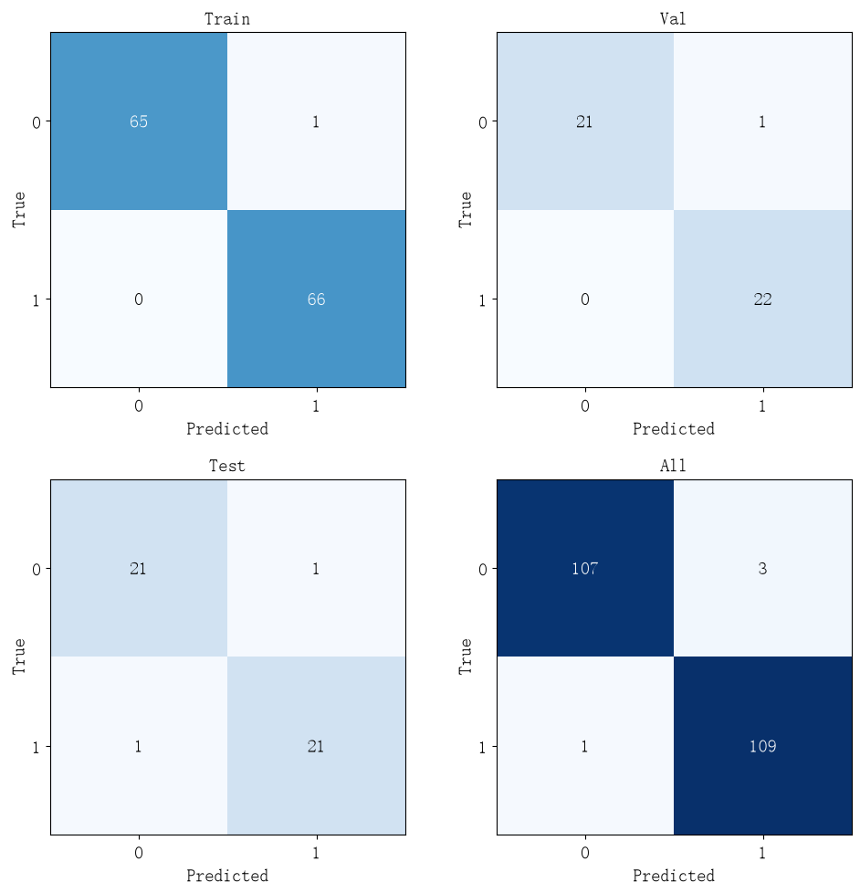

```python
title_list = ["Train", "Val", "Test", "All"]

vmax = max(confusion.max() for confusion in confusion_list)

fig, axes = plt.subplots(2, 2, figsize=(10, 10))

for ax, confusion, title in zip(axes.flat, confusion_list, title_list):
    im = ax.imshow(confusion, cmap="Blues", vmin=0, vmax=vmax)

    for i in range(2):
        for j in range(2):
            ax.text(
                j, i, confusion[i, j],
                ha="center", va="center",
                color="white" if confusion[i, j] > vmax / 2 else "black"
            )

    ax.set_xticks([0, 1])
    ax.set_yticks([0, 1])

    ax.set_xticklabels(["0", "1"])
    ax.set_yticklabels(["0", "1"])

    ax.set_xlabel("Predicted")
    ax.set_ylabel("True")
    ax.set_title(title)

display_inline(fig)
```

Train 中仅有 $1$ 个样本分类错误，Val 中也只有 $1$ 个样本分类错误，Test 中则有 $2$ 个样本分类错误. 说明模型在训练集上具有较高的拟合精度，同时在未参与训练的测试集上仍保持较好的分类能力.

从错误类型来看，Train 和 Val 中均只有 FP，没有 FN；Test 中 FP 和 FN 各有 $1$ 个. 对全部 $220$ 个样本，模型共出现 $4$ 次错误，其中 $3$ 次为 FP，$1$ 次为 FN.

总体而言，模型能够较好地区分两个类别，没有出现大量样本被错误分类的现象.

### Acc, Precision, Recall， F1

进一步根据四个混淆矩阵计算 Accuracy、Precision、Recall 和 F1.

$$ \mathrm{Accuracy}= \frac{TP+TN}{TP+TN+FP+FN} $$

$$ \mathrm{Precision}= \frac{TP}{TP+FP} $$

$$ \mathrm{Recall}= \frac{TP}{TP+FN} $$

$$ F_1= \frac{2TP}{2TP+FP+FN} $$

分别对 Train、Val、Test 和 All 计算这些指标, 可以进一步比较模型在不同数据集上的分类性能.

```python
def classification_metrics(confusion):
    TN, FP = confusion[0]
    FN, TP = confusion[1]

    accuracy = (TP + TN) / (TP + TN + FP + FN)

    precision = TP / (TP + FP) if TP + FP > 0 else 0.0
    recall = TP / (TP + FN) if TP + FN > 0 else 0.0
    f1 = 2 * TP / (2 * TP + FP + FN) if 2 * TP + FP + FN > 0 else 0.0

    return accuracy, precision, recall, f1


metrics = pd.DataFrame(
    [classification_metrics(c) for c in confusion_list],
    index=["Train", "Val", "Test", "All"],
    columns=["Accuracy", "Precision", "Recall", "F1"]
)

display(metrics)
```

|  | Accuracy | Precision | Recall | F1 |
| --- | --- | --- | --- | --- |
| Train | 0.992424 | 0.985075 | 1.000000 | 0.992481 |
| Val | 0.977273 | 0.956522 | 1.000000 | 0.977778 |
| Test | 0.954545 | 0.954545 | 0.954545 | 0.954545 |
| All | 0.981818 | 0.973214 | 0.990909 | 0.981982 |

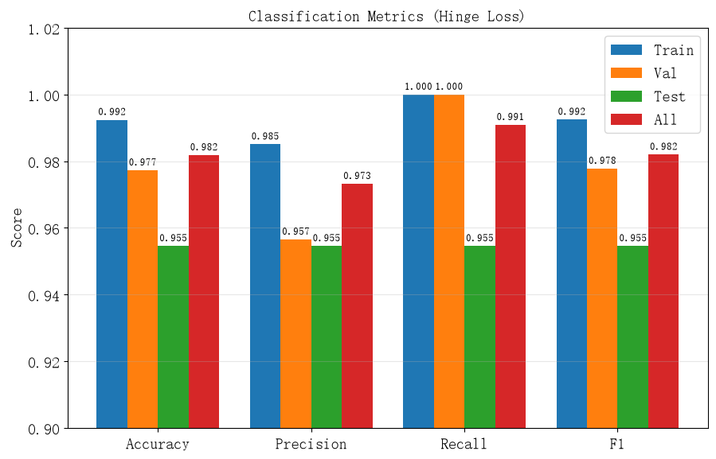

```python
metric_names = metrics.columns
dataset_names = metrics.index

x = np.arange(len(metric_names))
width = 0.2

fig, ax = plt.subplots(figsize=(10, 6))

for i, dataset in enumerate(dataset_names):
    offset = (i - 1.5) * width

    bars = ax.bar(
        x + offset,
        metrics.loc[dataset],
        width,
        label=dataset
    )

    ax.bar_label(
        bars,
        fmt="%.3f",
        padding=3,
        fontsize=9
    )

ax.set_xticks(x)
ax.set_xticklabels(metric_names)

ax.set_ylim(0.9, 1.02)

ax.set_ylabel("Score")
ax.set_title("Classification Metrics (Hinge Loss)")

ax.grid(True, axis="y", alpha=0.3)
ax.legend(loc="upper right")

display_inline(fig)
```

从图表中可以看到：

1. **Accuracy**：Train、Val 和 Test 的准确率分别为 $99.24\%$、$97.73\%$ 和 $95.45\%$. 测试集准确率略低于训练集，但整体仍处于较高水平，说明模型对未见数据具有一定的泛化能力.
2. **Precision**：Test 的 Precision 为 $95.45\%$，说明被预测为正类的样本中，有少量实际属于负类. Train 和 Val 的 Precision 略高于 Test.
3. **Recall**：Train 和 Val 的 Recall 均为 $1$，说明这两个数据集中的正类样本全部被正确识别. Test 的 Recall 为 $95.45\%$，对应 $1$ 个正类样本被错误分类为负类.
4. **F1 Score**：Train、Val 和 Test 的 F1 分别为 $0.9925$、$0.9778$ 和 $0.9545$，说明模型在训练集和未见数据上都能保持较好的 Precision 与 Recall 平衡.

综合来看，基于高阶多项式特征的 Hinge Loss 模型能够较好地拟合双月牙数据，测试集上的四个分类指标均达到约 $95.45\%$.

## 和 Logistic 回归模型对比

### Logicstic 回归模型训练

为了比较 Hinge Loss 和 Logistic Regression 的分类性能，我们使用相同的训练集、验证集和测试集，并采用相同的多项式特征及标准化参数.

两种模型均通过最小 Val Loss 选择学习率及最优 Epoch，以比较它们在相同特征空间下的分类效果.

```python
@nb.njit
def sigmoid(z):
    return 1.0 / (1.0 + np.exp(-z))


@nb.njit
def bce_loss(X, y, w, b):
    y_pred = sigmoid(X @ w + b)
    y_pred = np.clip(y_pred, 1e-12, 1 - 1e-12)

    return -np.mean(
        y * np.log(y_pred)
        + (1 - y) * np.log(1 - y_pred)
    )


@nb.njit
def train_logistic(
    X_train, y_train, X_val, y_val,
    learning_rate, epochs, w_init, b_init
):
    m = X_train.shape[0]

    w = w_init.copy()
    b = b_init

    train_loss = np.empty(epochs, dtype=np.float64)
    val_loss = np.empty(epochs, dtype=np.float64)

    best_w = w.copy()
    best_b = b
    best_val_loss = np.inf

    for epoch in range(epochs):
        y_pred = sigmoid(X_train @ w + b)
        error = y_pred - y_train

        dw = X_train.T @ error / m
        db = np.mean(error)

        w -= learning_rate * dw
        b -= learning_rate * db

        train_loss[epoch] = bce_loss(X_train, y_train, w, b)
        val_loss[epoch] = bce_loss(X_val, y_val, w, b)

        if val_loss[epoch] < best_val_loss:
            best_val_loss = val_loss[epoch]
            best_w = w.copy()
            best_b = b

    return best_w, best_b, train_loss, val_loss
```

为了保证 Logistic 回归也是最优的，同样扫描学习率，并选取 Val Loss 最低的作为最优参数，和 Hinge Loss 模型对比.

```python
@nb.njit
def scan_learning_rate_logistic(
    X_train, y_train, X_val, y_val,
    learning_rates, epochs, w_init, b_init
):
    n = len(learning_rates)

    train_loss_min = np.empty(n, dtype=np.float64)
    val_loss_min = np.empty(n, dtype=np.float64)
    best_epoch = np.empty(n, dtype=np.int64)

    for k in range(n):
        _, _, train_loss, val_loss = train_logistic(
            X_train, y_train,
            X_val, y_val,
            learning_rates[k], epochs,
            w_init, b_init
        )

        index = np.argmin(val_loss)

        train_loss_min[k] = train_loss[index]
        val_loss_min[k] = val_loss[index]
        best_epoch[k] = index + 1

    return train_loss_min, val_loss_min, best_epoch


learning_rates_logistic = np.logspace(-4, 0, 31)
epochs_logistic = 10000

t_start = time.time()
print("开始扫描 Logistic 回归学习率......")

train_loss_lr_logistic, val_loss_lr_logistic, best_epoch_lr_logistic = scan_learning_rate_logistic(
    Phi_train_lr, y_train,
    Phi_val_lr, y_val,
    learning_rates_logistic, epochs_logistic,
    w_init_lr, b_init_hyper
)

best_index_logistic_lr = np.argmin(val_loss_lr_logistic)
best_learning_rate_logistic = learning_rates_logistic[best_index_logistic_lr]

print(f"计算结束. 用时 {time.time() - t_start:.3f} s")
```

```
开始扫描 Logistic 回归学习率......
计算结束. 用时 17.001 s
```

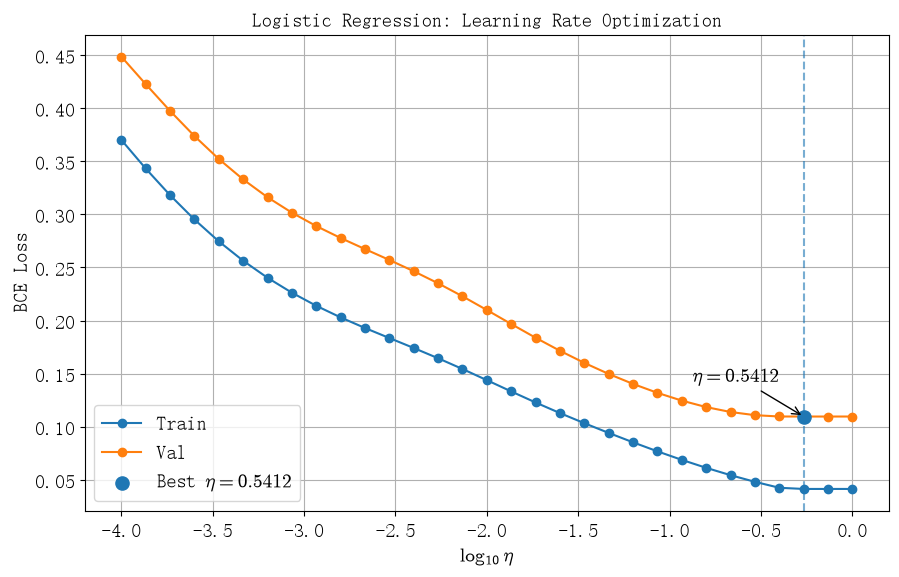

```python
log_lr_logistic = np.log10(learning_rates_logistic)
best_log_lr_logistic = log_lr_logistic[best_index_logistic_lr]

fig, ax = plt.subplots(figsize=(10, 6))

ax.plot(log_lr_logistic, train_loss_lr_logistic, marker="o", label="Train")
ax.plot(log_lr_logistic, val_loss_lr_logistic, marker="o", label="Val")

ax.scatter(
    best_log_lr_logistic,
    val_loss_lr_logistic[best_index_logistic_lr],
    s=90, zorder=3,
    label=fr"Best $\eta={best_learning_rate_logistic:.4g}$"
)

ax.axvline(best_log_lr_logistic, linestyle="--", alpha=0.6)

ax.annotate(
    fr"$\eta={best_learning_rate_logistic:.4g}$",
    xy=(
        best_log_lr_logistic,
        val_loss_lr_logistic[best_index_logistic_lr]
    ),
    xytext=(-80, 25),
    textcoords="offset points",
    arrowprops=dict(arrowstyle="->")
)

ax.set_xlabel(r"$\log_{10}\eta$")
ax.set_ylabel("BCE Loss")
ax.set_title("Logistic Regression: Learning Rate Optimization")
ax.grid(True)
ax.legend()

display_inline(fig)
```

可以看见，在学习率 $\eta = 0.5412$ 时，Val Loss 最小，因此我们选取这个学习率作为 Logistic 模型的学习率.

```python
w_logistic, b_logistic, train_loss_logistic, val_loss_logistic = train_logistic(
    Phi_train_lr, y_train,
    Phi_val_lr, y_val,
    best_learning_rate_logistic, epochs_logistic,
    w_init_lr, b_init_hyper
)

best_epoch_logistic = np.argmin(val_loss_logistic) + 1
```

此时模型的 Loss 曲线为：

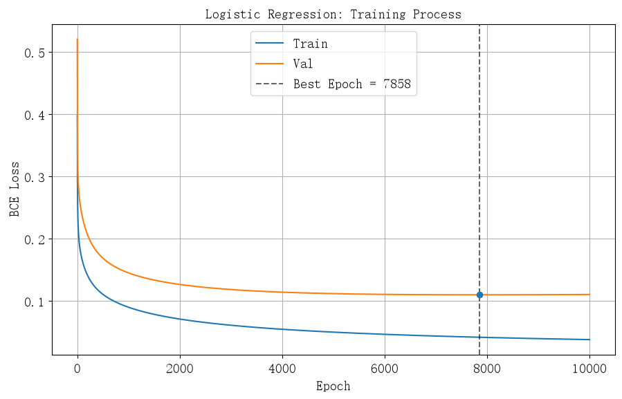

```python
epoch_logistic = np.arange(1, epochs_logistic + 1)

fig, ax = plt.subplots(figsize=(10, 6))

ax.plot(epoch_logistic, train_loss_logistic, label="Train")
ax.plot(epoch_logistic, val_loss_logistic, label="Val")

ax.axvline(
    best_epoch_logistic,
    linestyle="--", color="black", alpha=0.6,
    label=f"Best Epoch = {best_epoch_logistic}"
)

ax.scatter(
    best_epoch_logistic,
    val_loss_logistic[best_epoch_logistic - 1],
    zorder=3
)

ax.set_xlabel("Epoch")
ax.set_ylabel("BCE Loss")
ax.set_title("Logistic Regression: Training Process")
ax.grid(True)
ax.legend()

display_inline(fig)
```

可见，我们的 Loss 曲线也是标准的“欠学习-过学习”过程， Val Loss 先降后升（图中不是很明显），Train Loss 一直下降.

和 Hinge Loss 不同的是，由于没有使用随机梯度下降，这里的曲线比 Hinge Loss 的更光滑.

### 模型对比

画出两个模型的分类边界，有：

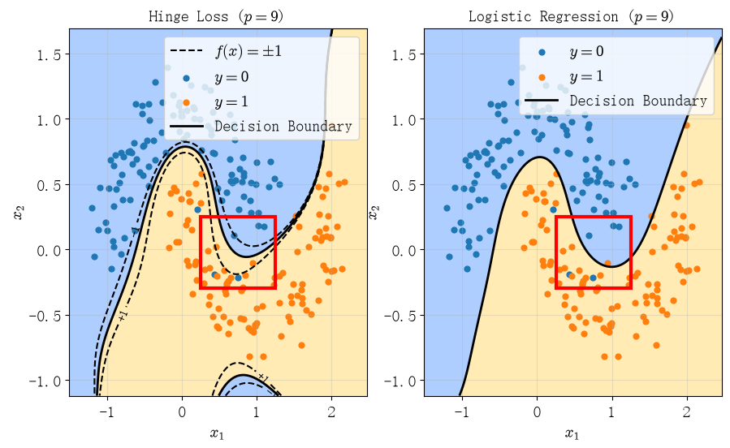

```python
grid_size = 350
padding = 0.3

x1 = np.linspace(
    X[:, 0].min() - padding,
    X[:, 0].max() + padding,
    grid_size
)
x2 = np.linspace(
    X[:, 1].min() - padding,
    X[:, 1].max() + padding,
    grid_size
)

xx1, xx2 = np.meshgrid(x1, x2)
X_grid = np.column_stack((xx1.ravel(), xx2.ravel()))

Phi_grid = polynomial_features(X_grid, p_fixed)
Phi_grid = (Phi_grid - feature_mean_lr) / feature_std_lr

F_hinge = (Phi_grid @ w_best + b_best).reshape(xx1.shape)
F_logistic = (Phi_grid @ w_logistic + b_logistic).reshape(xx1.shape)

fig, axes = plt.subplots(1, 2, figsize=(10,6))


# 指定矩形框范围（数据坐标）
x_min, x_max = 0.25, 1.25
y_min, y_max = 0.25, -0.3

for ax, F, name in zip(
    axes,
    [F_hinge, F_logistic],
    ["Hinge Loss", "Logistic Regression"]
):
    regions = (F >= 0).astype(np.int64)

    ax.contourf(
        xx1, xx2, regions,
        levels=[-0.5, 0.5, 1.5],
        colors=["#83B5FF", "#FFE18A"],
        alpha=0.65
    )

    # 分类边界 f(x) = 0
    ax.contour(
        xx1, xx2, F,
        levels=[0],
        colors="black",
        linewidths=2
    )

    rect = mpl.patches.Rectangle(
        (x_min, y_min),
        x_max - x_min,
        y_max - y_min,
        fill=False,
        edgecolor="red",
        linewidth=3,
        zorder=10
    )
    ax.add_patch(rect)

    # Hinge Loss: f(x) = -1, +1
    if name == "Hinge Loss":
        cs = ax.contour(
            xx1, xx2, F,
            levels=[-1, 1],
            colors="black",
            linestyles="--",
            linewidths=1.5
        )
        ax.clabel(
            cs,
            fmt={-1: "-1", 1: "+1"},
            fontsize=10,
            inline=True
        )

        ax.plot([], [], "k--", label=r"$f(x)=\pm1$")

    for label in [0, 1]:
        ax.scatter(
            X[y == label, 0],
            X[y == label, 1],
            c=f"C{label}",
            s=24,
            label=fr"$y={label}$"
        )

    ax.plot([], [], "k-", linewidth=2, label="Decision Boundary")

    ax.set_xlabel(r"$x_1$")
    ax.set_ylabel(r"$x_2$")
    ax.set_title(fr"{name} ($p={p_fixed}$)")
    ax.grid(True, alpha=0.3)
    ax.legend()

display_inline(fig)
```

从分类边界对比图可以看到，两种模型都能够较好地拟合双月牙数据的非线性分布，大部分样本位于正确的分类区域内.

两者的主要区别在于分类边界的局部形状：

1. **Hinge Loss**：分类边界受噪声点干扰较小. 图中红色区域中分类边界没有受到其中有噪声的蓝色点的较大影响而更靠下.
2. **Logistic Regression**：分类边界较容易受到噪声干扰，图中分类边界为了更靠近明显噪声的蓝色点而更靠下，导致错误分类的噪声较小的橙色点.

进一步计算两种模型的 Acc Precision Recall F1 值.

```python
dataset_names_compare = ["Train", "Val", "Test", "All"]

Phi_list_compare = [
    Phi_train_lr,
    Phi_val_lr,
    Phi_test_lr
]

y_list_compare = [y_train, y_val, y_test]

confusion_hinge_compare = []
confusion_logistic_compare = []

y_pred_hinge_list = []
y_pred_logistic_list = []

for Phi, y_true in zip(Phi_list_compare, y_list_compare):
    y_pred_hinge = predict_hinge(Phi, w_best, b_best)

    y_pred_logistic = (
        sigmoid(Phi @ w_logistic + b_logistic) >= 0.5
    ).astype(np.int64)

    y_pred_hinge_list.append(y_pred_hinge)
    y_pred_logistic_list.append(y_pred_logistic)

    confusion_hinge_compare.append(
        confusion_matrix(y_true, y_pred_hinge)
    )
    confusion_logistic_compare.append(
        confusion_matrix(y_true, y_pred_logistic)
    )

# All
y_all_compare = np.concatenate(y_list_compare)

confusion_hinge_compare.append(
    confusion_matrix(
        y_all_compare,
        np.concatenate(y_pred_hinge_list)
    )
)

confusion_logistic_compare.append(
    confusion_matrix(
        y_all_compare,
        np.concatenate(y_pred_logistic_list)
    )
)

# 计算四项指标
metric_columns_compare = ["Accuracy", "Precision", "Recall", "F1"]

metrics_hinge_compare = pd.DataFrame(
    [classification_metrics(c) for c in confusion_hinge_compare],
    index=pd.Index(dataset_names_compare, name="Dataset"),
    columns=metric_columns_compare
)

metrics_logistic_compare = pd.DataFrame(
    [classification_metrics(c) for c in confusion_logistic_compare],
    index=pd.Index(dataset_names_compare, name="Dataset"),
    columns=metric_columns_compare
)

metrics_compare = pd.concat(
    {
        "Hinge": metrics_hinge_compare,
        "Logistic": metrics_logistic_compare
    },
    names=["Model"]
)

display(metrics_compare)
```

| Model | Dataset | Accuracy | Precision | Recall | F1 |
| --- | --- | --- | --- | --- | --- |
| Hinge | Train | 0.992424 | 0.985075 | 1.000000 | 0.992481 |
|  | Val | 0.977273 | 0.956522 | 1.000000 | 0.977778 |
|  | Test | 0.954545 | 0.954545 | 0.954545 | 0.954545 |
|  | All | 0.981818 | 0.973214 | 0.990909 | 0.981982 |
| Logistic | Train | 0.992424 | 0.985075 | 1.000000 | 0.992481 |
|  | Val | 0.954545 | 0.954545 | 0.954545 | 0.954545 |
|  | Test | 0.954545 | 0.954545 | 0.954545 | 0.954545 |
|  | All | 0.977273 | 0.972973 | 0.981818 | 0.977376 |

对比两种模型的 Acc：

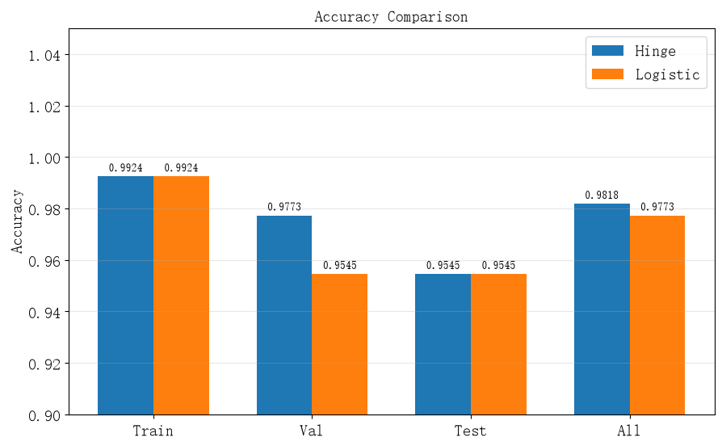

```python
x = np.arange(len(dataset_names_compare))
width = 0.35

fig, ax = plt.subplots(figsize=(10, 6))

for i, (model_name, model_metrics) in enumerate([
    ("Hinge", metrics_hinge_compare),
    ("Logistic", metrics_logistic_compare)
]):
    offset = (i - 0.5) * width

    bars = ax.bar(
        x + offset,
        model_metrics["Accuracy"].to_numpy(),
        width,
        label=model_name
    )

    ax.bar_label(
        bars,
        fmt="%.4f",
        padding=3,
        fontsize=10
    )

ax.set_xticks(x)
ax.set_xticklabels(dataset_names_compare)

ax.set_ylim(0.90, 1.05)
ax.set_ylabel("Accuracy")
ax.set_title("Accuracy Comparison")

ax.grid(True, axis="y", alpha=0.3)
ax.legend()

display_inline(fig)
```

从 Accuracy 对比图和四项分类指标可以看到，两种模型整体表现非常接近，但在不同数据集上存在一些差异.

1. **Train**：Hinge Loss 和 Logistic Regression 的 Accuracy 均为 $99.24\%$，Precision、Recall 和 F1 也完全相同. 说明两种模型对训练样本具有相同的分类表现.
2. **Val**：Hinge Loss 的 Accuracy 为 $97.73\%$，高于 Logistic Regression 的 $95.45\%$. 对应的错误分类数量分别为 $1$ 和 $2$，Hinge Loss 在验证集上略占优势. 其 Recall 和 F1 也高于 Logistic Regression.
3. **Test**：两种模型的 Accuracy、Precision、Recall 和 F1 均为 $95.45\%$，各有 $2$ 个样本分类错误. 说明在当前独立测试集上，两种模型表现相同，没有观察到明显的泛化性能差异.
4. **All**：Hinge Loss 的整体 Accuracy 为 $98.18\%$，Logistic Regression 为 $97.73\%$，分别对应 $4$ 和 $5$ 个错误分类样本. Hinge Loss 的整体指标略高，但差异较小.

综合来看，两种损失函数均能够有效训练非线性二分类模型. Hinge Loss 在本次实验的验证集和整体样本上略有优势.

## 结论

本次实验使用 Hinge Loss 对 `make_moons` 二分类数据集进行分类. 在原始二维输入特征的基础上构造多项式特征，使用随机梯度下降（SGD）进行模型训练，并进一步研究学习率、多项式阶数对模型的影响. 最后将 Hinge Loss 与 Logistic 回归模型进行对比. 得到如下结论：

- 原始 `make_moons` 数据具有明显的非线性分类边界. 仅使用低阶特征时模型表达能力不足. 通过加入满足 $1\le a+b\le p$ 的多项式特征，Hinge Loss 模型可以形成非线性分类边界. 同时，通过绘制 $f(\boldsymbol{x})=0$ 和 $f(\boldsymbol{x})=\pm1$ 的等值线，可以观察分类边界及其函数间隔.
- 对多项式阶数 $p=1\sim10$ 进行扫描后发现，当 $p$ 较小时，模型无法充分描述非线性分类边界. 当 $p\geq3$ 后，Val Acc 已达到约 $0.9773$，但 Val Loss 仍随阶数变化. 本实验根据最小 Val Loss 选取 $p=9$. 随后扫描学习率 $10^{-5}\leq\eta\leq1$，最终选取

$$ p=9,\qquad \eta\approx0.03162 $$

- 最终 Hinge Loss 模型在 Test 集中有 $2$ 个样本分类错误，对应四项分类指标为

$$ \mathrm{Accuracy}=0.9545 $$

$$ \mathrm{Precision}=0.9545 $$

$$ \mathrm{Recall}=0.9545 $$

$$ F_1=0.9545 $$

在全部 $220$ 个样本中共有 $4$ 个样本分类错误， 全部数据集上 Accuracy 为 $0.9818$. 最终分类边界能够较好地描述双月牙数据的非线性分布.

- 使用随机梯度下降训练 Hinge Loss 模型后发现，由于 SGD 每次根据单个样本更新参数，损失曲线存在一定的随机波动. 而使用全体参数更新的 Logistic Regression 的 Loss 曲线更光滑.
- 与 Logistic Regression 对比发现，两种模型在当前数据集上具有接近的分类性能. Hinge Loss 的 Val Accuracy 为 $0.9773$，高于 Logistic Regression 的 $0.9545$；但两者的 Test Accuracy 均为 $0.9545$. 从分类边界来看，Hinge Loss 在部分区域受噪声样本的影响较小，而 Logistic Regression 的边界在这些区域出现了不同程度的偏移.

综合来看，Hinge Loss 配合高阶多项式特征能够有效处理当前非线性二分类问题. 本实验最终选取

$$ p=9,\qquad\eta\approx0.03162 $$

作为最优超参数. 与 Logistic Regression 相比，Hinge Loss 略有优势.

## 参考资料和 AI 使用说明

- 背景补充部分个人写出大体大纲，使用 GPT 6 Astra 生成并进行人工核验和修改.
- 代码编写使用 Deepseek V4 Flash FIM 模式进行补全和生成（尤其是绘图相关函数，基本是直接生成），经过人工核验和运行验证.
- 扫参函数由 GPT 6 生成，经过人工核验和运行验证.
- 文本和公式编写使用 Deepseek V4 Flash FIM 模式进行生成和补全，经过人工核验和修改.
- 部分结果描述使用 GPT 6 给出，经过人工核验和修改.

## 致谢

暂无

## 附一：问题

### 问题 1：Batch Size 对 SGD 跳出局部最优的影响

SGD 通过随机抽取样本计算梯度，使参数更新具有一定的随机性，深度学习中，我们会设置一个 Batch Size，其描述每一次训练所使用的数据量，SDG 相当于取 Batch Size 为 1. 对于非凸损失函数，这种随机性可能帮助模型跳出局部极小值. 那么，不同的 Batch Size 如何影响这种能力？Batch Size 越小是否意味着越容易得到全局最优？

### 问题 2：特征尺度对 Hinge Loss 最大间隔的影响

Hinge Loss 常用于训练最大间隔分类器，但几何间隔是在特征空间中定义的. 如果原始输入发生很小变化就会引起某个特征的巨大变化，模型是否可能过度依赖该特征？应该如何避免？

实际上，特征空间中的大间隔并不一定意味着原始输入空间中的高鲁棒性. 对于一般特征映射，判别函数的微小变化近似满足

$$ \Delta f\approx \boldsymbol w^\mathsf T J_\phi(\boldsymbol x)\Delta\boldsymbol x $$

因此，即使 $\|\boldsymbol w\|$ 较小，如果特征映射的 Jacobian 很大，原始输入的微小扰动仍可能引起较大的输出变化. 从而使得我们最大化间隔最大化了特征空间的这个方向，从而使得并不能准确地最大化原始输入的间隔.

## 附二：学习心得

暂无